# Assignment 4: Rule-based categorization in the alien task

# Task

We modelled the alien categorisation task from the lectures. Each alien was represented as five binary features, giving 32 possible stimuli. In each session, all 32 stimuli were shown three times in randomised order. Participants responded with categories 1–4. Responses 3 and 4 meant “dangerous”, while responses 1 and 2 meant “not dangerous”.

We simplified the assignment by modelling only the danger dimension. This kept the model clear and identifiable while still targeting the central categorisation problem. The true danger rule changed across sessions. In session 1, danger depended on feature 1 AND feature 3. In session 2, danger depended on feature 4. In session 3, danger depended on feature 4 AND feature 5.

# Model

We used a simple rule-based categorisation model. This was appropriate because the task was generated by explicit feature rules rather than by vague similarity gradients. The model considered a small set of candidate rules: two baseline rules, five single-feature rules, and all ten two-feature AND rules.

Before learning, all rules had equal weight. On each trial, every rule predicted whether the alien was dangerous. The agent responded according to a weighted vote over rules, with an epsilon parameter allowing response noise. After feedback, rules that predicted correctly gained weight, while rules that predicted incorrectly lost weight. Rule weights were reset between sessions because the true danger rule changed.

For inference, we used a simpler Stan model. The Stan model did not implement full trial-by-trial learning. Instead, it estimated which mixture of candidate rules best explained one session of responses, and how much response noise was needed. This gave us a practical pass-level inferential model while keeping the workflow close to the course examples.

# Simulation

The simulated rule learner performed as intended. Across 50 simulated agents, danger accuracy improved rapidly within each session and stabilized well above chance. Mean accuracy was already high in the first cycle and increased further in later cycles.

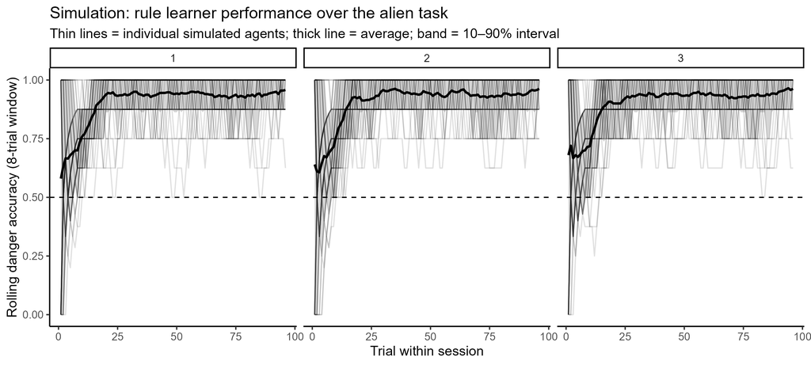

Figure 1. Simulated rule learner perfomance across the alien task

The final rule weights showed that the model converged on the correct danger rule in each session. In session 1, the surviving rule was f1 AND f3. In session 2, it was f4 = 1. In session 3, it was f4 AND f5. This shows that the forward model can solve the formalized version of the task.

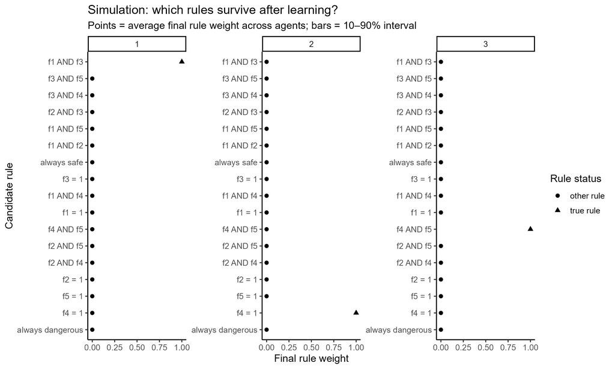

Figure 2. Final simulated rule weights after learning

# Fit to simulated data

We fit the Stan rule-mixture model to simulated session-1 data. Diagnostics were acceptable, with Rhat close to 1 and good effective sample sizes. The posterior for epsilon moved toward low values, suggesting mostly rule-consistent responding.

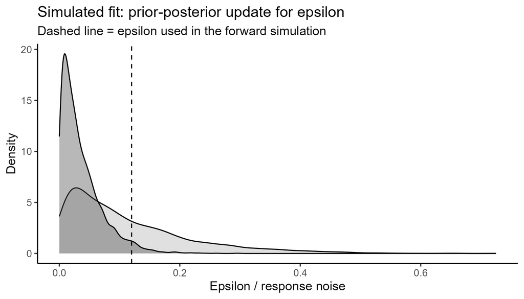

Figure 3. Prior-posterior update for epsilon in the simulated fit

The posterior rule weights identified the correct session-1 rule. The highest posterior weight was assigned to f1 AND f3. Some uncertainty remained, especially for simpler rules that were partly correlated with the true rule. This is expected because the task is short and the features overlap.

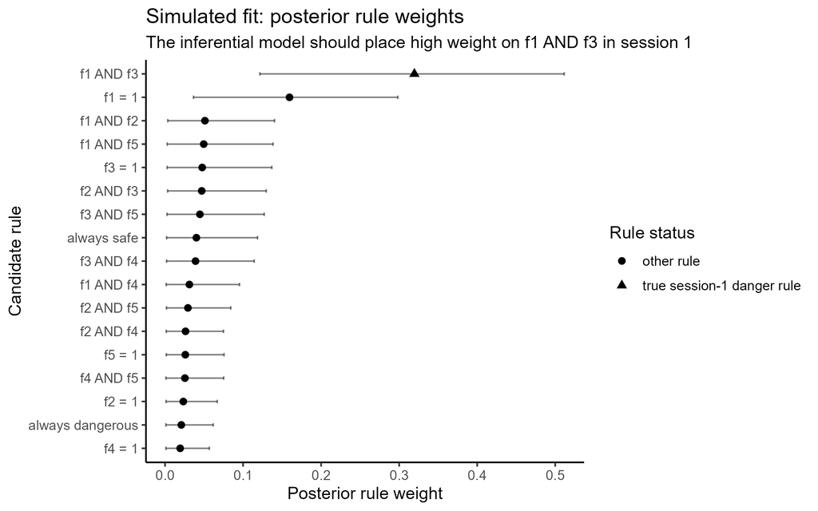

Figure 4. Posterior rule weights for the simulated session-1 fit

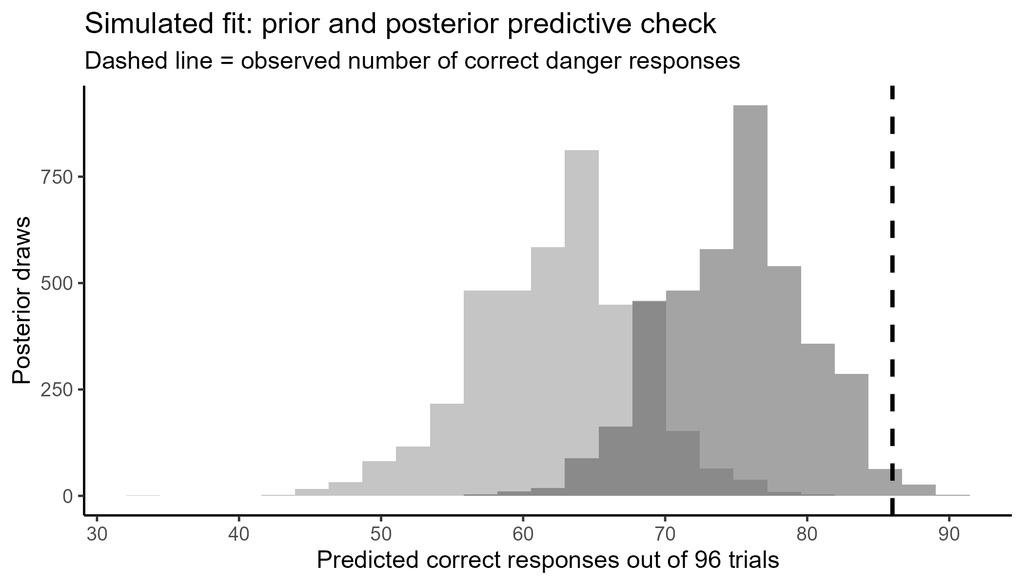

Figure 5. Prior and posterior predictive check for the simulated fit

# Empirical data

We then explored the empirical AlienData. We recoded responses 3 and 4 as danger responses and compared them to the task-defined danger category. The empirical data showed learning across trials, but participants were noisier than the simulated agents. Session 2 showed the clearest learning, while session 3 was less stable.

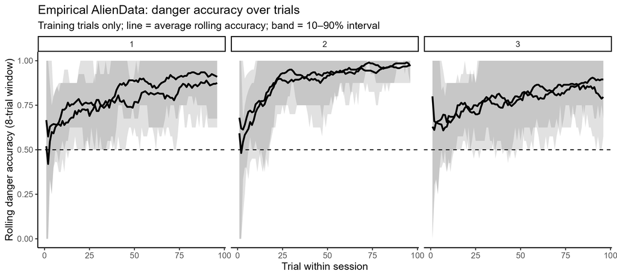

Figure 6. Empirical danger accuracy over trials

For the empirical Stan fit, we used one condition, one participant, and session 1 only. This gave 96 training trials. The selected participant had 83 correct danger responses, corresponding to accuracy .865. This follows the assignment instruction that fitting one participant and one session is sufficient.

The empirical fit had acceptable diagnostics. The posterior for epsilon again moved toward low values, suggesting mostly rule-consistent responding, but with some noise.

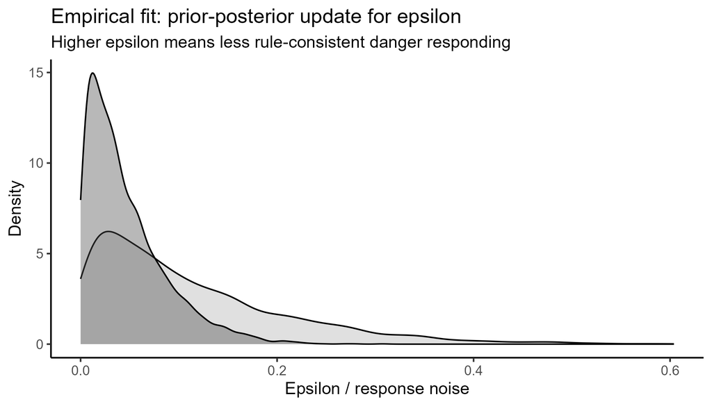

Figure 7. Prior-posterior update for epsilon in the empirical fit

The empirical rule weights were more ambiguous than the simulated rule weights. The true rule, f1 AND f3, received substantial posterior weight, but the simpler rule f1 = 1 received very similar support. This suggests that the selected participant may have used a simpler heuristic rather than consistently applying the full conjunctive rule.

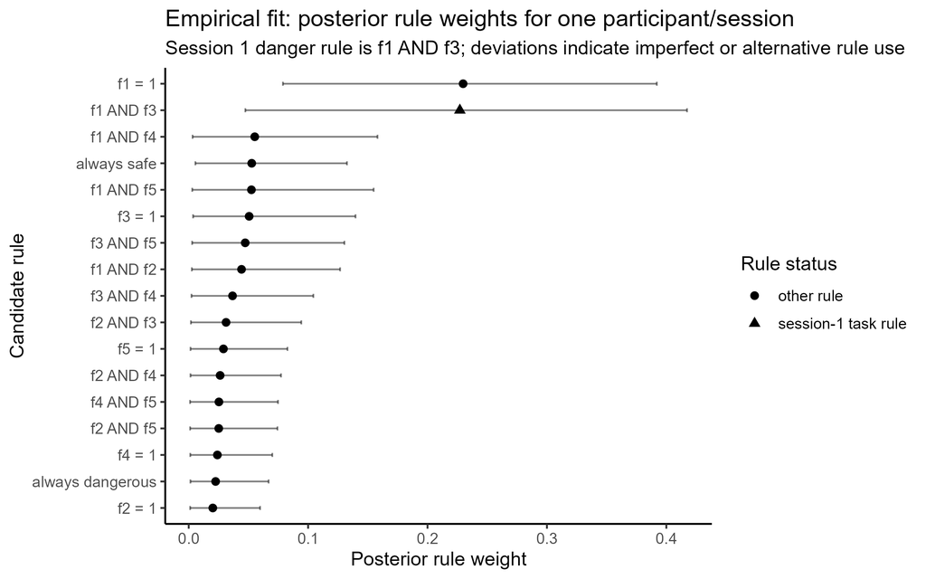

Figure 8. Posterior rule weights for one empirical participant in session 1

The empirical posterior predictive check improved over the prior predictive distribution, but still underpredicted the observed number of correct danger responses. The model therefore captured part of the participant’s behavior, but not all of it.

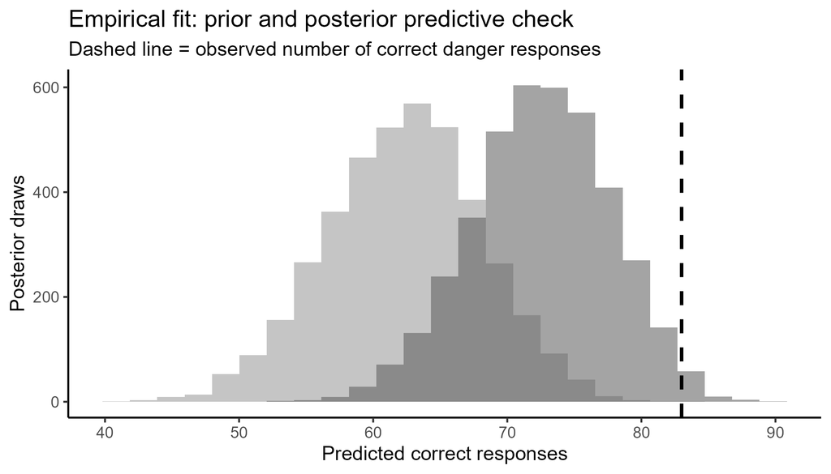

Figure 9. Prior and posterior predictive check for the empirical fit

# Discussion

We implemented a simple formal model of categorization for the alien task. The simulation showed that a rule-learning agent can learn the changing danger rules and reach high performance. The fitted Stan model also behaved sensibly: it updated epsilon toward low noise and placed high weight on the correct rule in simulated data.

The model fit was not perfect. In both simulated and empirical data, the posterior predictive distribution underpredicted the observed number of correct responses. We interpret this as a limitation of the fitted model rather than a failure of the whole approach. The simulated agent learned dynamically over trials, while the Stan model summarized behaviour with one static mixture of rules.

The empirical analysis was especially informative. The selected participant performed well, but the posterior did not uniquely identify the true conjunctive rule. Instead, it assigned similar support to f1 = 1 and f1 AND f3. This suggests that human participants may rely on simplified heuristics, especially when rules are correlated.

The main limitations are that we modelled only danger, fit only one empirical session, ignored the dyad/individual contrast, and used a static inferential model. A fuller version would include nutrition, fit all sessions, and implement the dynamic rule update directly in Stan or in a multilevel model. For the present assignment, however, the model completes the core workflow: we formalised the task, simulated a cognitive model, fit the model to simulated data, checked the fit, and applied it cautiously to empirical behaviour.